# Lab 5

FIRSTNAME LASTNAME

October 16, 2018

# Instructions

**Exercises:** 1,3 (Pg. 227); 2 (Pg. 232); 1,2 (Pg. 235);

**Assigned:** Friday, October 12, 2018

**Due:** Friday, October 19, 2018 by 5:00 PM

**Submission:** Submit via an electronic document on Sakai. Must be submitted as a HTML file generated in RStudio. All assigned problems are chosen according to the textbook *R for Data Science*. You do not need R code to answer every question. If you answer without using R code, delete the code chunk. If the question requires R code, make sure you display R code. If the question requires a figure, make sure you display a figure. A lot of the questions can be answered in written response, but require R code and/or figures for understanding and explaining.

# Chapter 12 (Pg. 227)

## Exercise 1

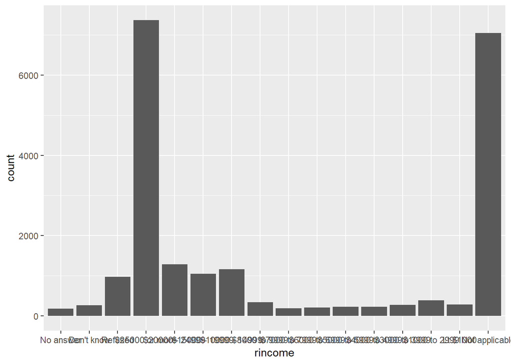

```r
ggplot(gss_cat, aes(x = rincome)) + geom_bar() + scale_x_discrete(drop = FALSE)
```

```r
#
```

There are too many bins in the data to make a useful chart. Another option is to shorten the labels for the bins.

## Exercise 3

```r
table(gss_cat$relig, gss_cat$denom)
```

```
##
##                           No answer Don't know No denomination Other
##   No answer                      93          0               0     0
##   Don't know                      0          0               0     0
##   Inter-nondenominational         0          0               0     0
##   Native american                 0          0               0     0
##   Christian                       2         11             452     0
##   Orthodox-christian              0          0               0     0
##   Moslem/islam                    0          0               0     0
##   Other eastern                   0          0               0     0
##   Hinduism                        0          0               0     0
##   Buddhism                        0          0               0     0
##   Other                           0          0               7     0
##   None                            0          0               0     0
##   Jewish                          0          0               0     0
##   Catholic                        0          0               0     0
##   Protestant                     22         41            1224  2534
##   Not applicable                  0          0               0     0
##
##                           Episcopal Presbyterian-dk wh
##   No answer                       0                  0
##   Don't know                      0                  0
##   Inter-nondenominational         0                  0
##   Native american                 0                  0
##   Christian                       0                  0
##   Orthodox-christian              0                  0
##   Moslem/islam                    0                  0
##   Other eastern                   0                  0
##   Hinduism                        0                  0
##   Buddhism                        0                  0
##   Other                           0                  0
##   None                            0                  0
##   Jewish                          0                  0
##   Catholic                        0                  0
##   Protestant                    397                244
##   Not applicable                  0                  0
##
##                           Presbyterian, merged Other presbyterian
##   No answer                                  0                  0
##   Don't know                                 0                  0
```

[output cut: 179 more lines]

```
##   Don't know                              0               0             15
##   Inter-nondenominational                 0               0            109
##   Native american                         0               0             23
##   Christian                               0               0            224
##   Orthodox-christian                      0               0             95
##   Moslem/islam                            0               0            104
##   Other eastern                           0               0             32
##   Hinduism                                0               0             71
##   Buddhism                                0               0            147
##   Other                                   0               0            217
##   None                                    0               0           3523
##   Jewish                                  0               0            388
##   Catholic                                0               0           5124
##   Protestant                            130             237              0
##   Not applicable                          0               0              0
```

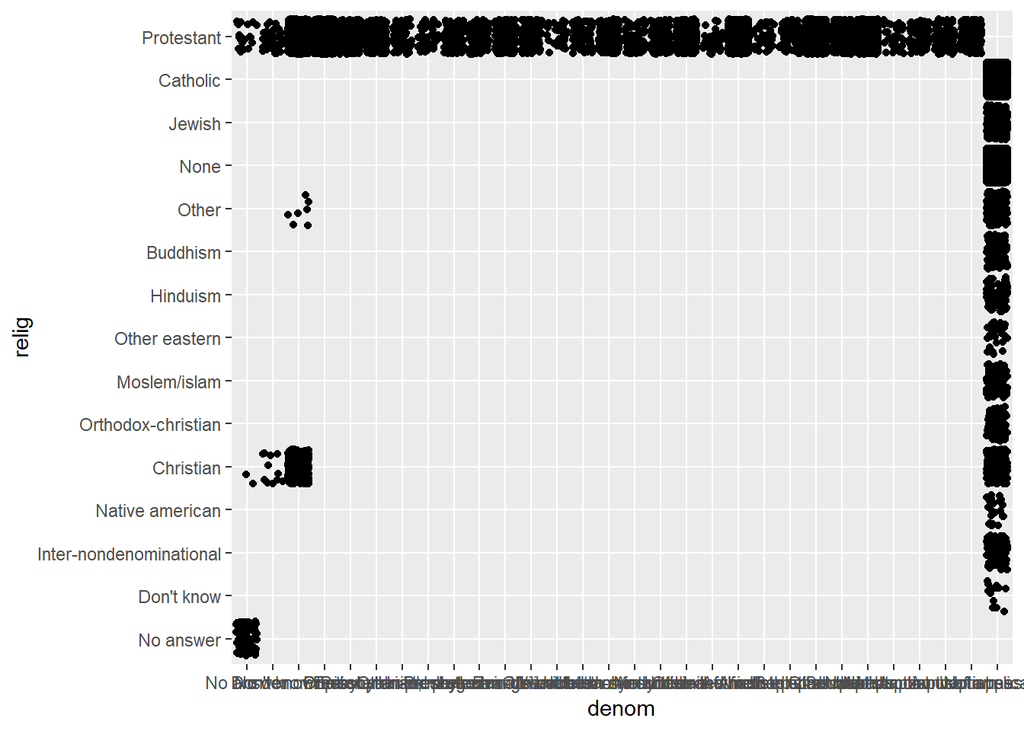

```r
ggplot(gss_cat, aes(denom, relig)) + geom_jitter()
```

```r
#
```

Denomination applies to only Protestants.

# Chapter 12 (Pg. 232)

## Exercise 2

```r
head(gss_cat)
```

```
## # A tibble: 6 x 9
##    year marital     age race  rincome   partyid    relig   denom   tvhours
##   <int> <fct>     <int> <fct> <fct>     <fct>      <fct>   <fct>     <int>
## 1  2000 Never ma~    26 White $8000 to~ Ind,near ~ Protes~ Southe~      12
## 2  2000 Divorced     48 White $8000 to~ Not str r~ Protes~ Baptis~      NA
## 3  2000 Widowed      67 White Not appl~ Independe~ Protes~ No den~       2
## 4  2000 Never ma~    39 White Not appl~ Ind,near ~ Orthod~ Not ap~       4
## 5  2000 Divorced     25 White Not appl~ Not str d~ None    Not ap~       1
## 6  2000 Married      25 White $20000 -~ Strong de~ Protes~ Southe~      NA
```

```r
#
```

# Chapter 12 (Pg. 235)

## Exercise 1

```r
gss_cat <- gss_cat %>% mutate(partyid = fct_collapse(partyid, other = c("No answer", "Don't know", "Other party"), ind = c("Independent", "Ind,near rep", "Ind,near dem"), rep = c("Strong republican", "Not str republican"), dem = c("Strong democrat", "Not str democrat")))



ted <- gss_cat %>% group_by(partyid, year) %>% summarise(total = n() )
ted
```

```
## # A tibble: 32 x 3
## # Groups:   partyid [?]
##    partyid  year total
##    <fct>   <int> <int>
##  1 other    2000    60
##  2 other    2002    84
##  3 other    2004    41
##  4 other    2006    91
##  5 other    2008    51
##  6 other    2010    65
##  7 other    2012    68
##  8 other    2014    88
##  9 rep      2000   684
## 10 rep      2002   764
## # ... with 22 more rows
```

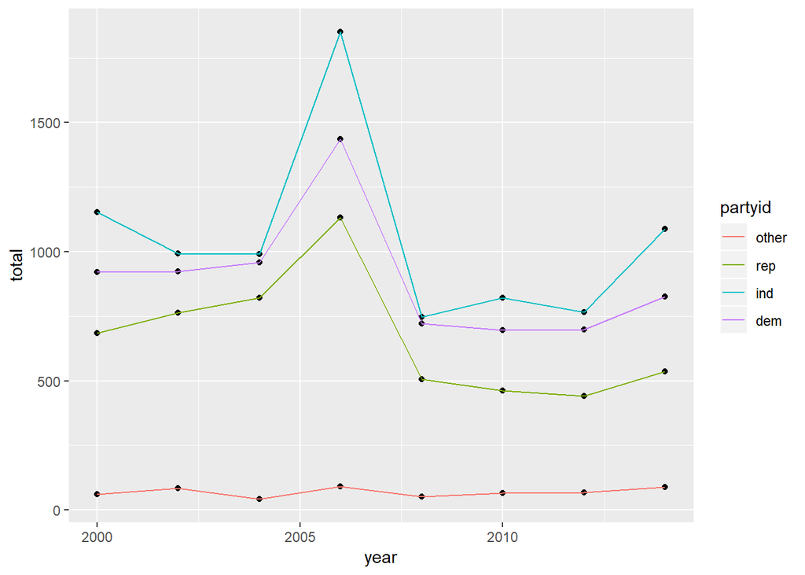

```r
ggplot(ted, aes(year, total)) + geom_point() + geom_line(aes(colour = partyid))
```

```r
#
```

## Exercise 2

```r
#
```

You could combine the inner bins into smaller sections.